# Resampling example

Joey Burant

1/29/2022

This is a quick example of how to resample the data and plot the distributions of sampled traits, making use of the `penguins` dataset from the `palmerpenguins` **R** package.

### Resampling the data using `dplyr::sample_()` and `base::replicate()`

We can easily randomly resample either a specific number of observations (using `dplyr::sample_n()`) or a set proportion of the data (using `dplyr::sample_frac()`). The `replicate()` function provides a really easy way to iterate this process a number of times.

The code chunk below uses two variables:

- `n_reps` = the number of desired replicates, which is passed to `replicate()` – in this case we want 100 replicates.
- `samp_prop` = the proportion of the data to resample, which is passed to `sample_frac()` – here we want to resample 50% of the data

By wrapping this in a tibble, we can create a tidy product in which the replicate samples are stored as a nested list that can be used for summarizing, analysis, and plotting.

```r
## remove NAs from the dataset and add a row (record) id column
## (so we can trace a sample back to the dataset if needed)
penguins_c <- penguins %>%
  drop_na() %>%
  mutate(id = row_number(),
         .before = species)

## specify the number of replicates and the sample prop (or size)
n_reps <- 100
samp_prop <- 0.50

## resample the data and put it in a tibble
re_penguins <- tibble(
  rep = 1:n_reps,
  samp = replicate(
    n = n_reps,
    sample_frac(
      tbl = penguins_c,
      size = samp_prop,
      replace = FALSE),
    simplify = FALSE))
```

What does this look like now?

```r
re_penguins
```

```
## # A tibble: 100 × 2
##      rep samp
##    <int> <list>
##  1     1 <tibble [166 × 9]>
##  2     2 <tibble [166 × 9]>
##  3     3 <tibble [166 × 9]>
##  4     4 <tibble [166 × 9]>
##  5     5 <tibble [166 × 9]>
##  6     6 <tibble [166 × 9]>
##  7     7 <tibble [166 × 9]>
##  8     8 <tibble [166 × 9]>
##  9     9 <tibble [166 × 9]>
## 10    10 <tibble [166 × 9]>
## # … with 90 more rows
```

### Summarizing the data

One way to summarize the dataset is to first `unnest()` it, then use the replicate identifier (`rep`) as a grouping variable.

In the chunk below, I first `unnest()` the data (stored in the `samp` column), then `group_by()` `rep` (100 levels), `species` (3 levels), and `sex` (2 levels). This example calculates the median value for each of the numeric columns in the dataset, before `nest`ing the summary data and `join`ing it back with the original data.

```r
## calculate the median trait values from each sample
re_penguins <- re_penguins %>%
  unnest(samp) %>%
  group_by(rep, species, sex) %>%
  summarise(across(.cols = bill_length_mm:body_mass_g,
                   ~ median(.))) %>%
  group_by(rep) %>%
  nest() %>%
  rename(summ_mean = data) %>%
  right_join(re_penguins, ., by = "rep") %>%
  suppressMessages()

re_penguins
```

```
## # A tibble: 100 × 3
##      rep samp               summ_mean
##    <int> <list>             <list>
##  1     1 <tibble [166 × 9]> <tibble [6 × 6]>
##  2     2 <tibble [166 × 9]> <tibble [6 × 6]>
##  3     3 <tibble [166 × 9]> <tibble [6 × 6]>
##  4     4 <tibble [166 × 9]> <tibble [6 × 6]>
##  5     5 <tibble [166 × 9]> <tibble [6 × 6]>
##  6     6 <tibble [166 × 9]> <tibble [6 × 6]>
##  7     7 <tibble [166 × 9]> <tibble [6 × 6]>
##  8     8 <tibble [166 × 9]> <tibble [6 × 6]>
##  9     9 <tibble [166 × 9]> <tibble [6 × 6]>
## 10    10 <tibble [166 × 9]> <tibble [6 × 6]>
## # … with 90 more rows
```

### Plotting

Finally, we can plot the distributions of the re-sampled data. The plot below overlays density distributions of `penguins$bill_length_mm` for each random sample of the dataset, facetting by `species` and `sex`.

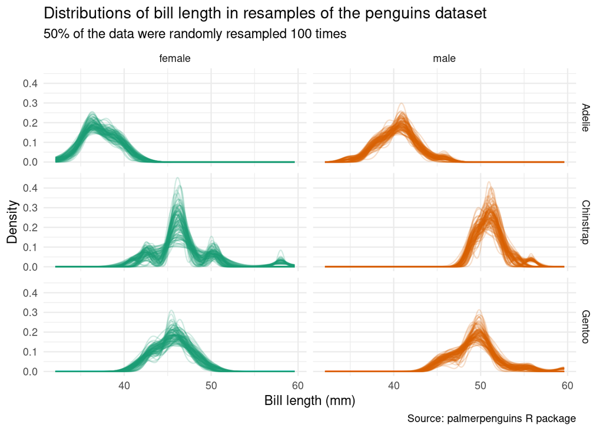

```r
## plot the distributions of bill_length_mm from the resamples
re_penguins %>%
  select(rep, samp) %>%
  unnest(samp) %>%
  ggplot(data = .,
         mapping = aes(x = bill_length_mm,
                       group = rep,
                       colour = sex)) +
  geom_line(stat = "density", alpha = 0.2) +
  scale_colour_brewer(palette = "Dark2") +
  # facet_wrap(~ species) +
  facet_grid(species ~ sex) +
  labs(x = "Bill length (mm)", y = "Density",
       title = "Distributions of bill length in resamples of the penguins dataset",
       subtitle = "50% of the data were randomly resampled 100 times",
       caption = "Source: palmerpenguins R package") +
  theme_minimal() +
  theme(legend.position = "none")
```

This plot provides a good starting point for thinking about how to calculate a 95% confidence interval on the distributions based on the distribution of resamples. Of course, the same approach could also be used to estimate confidence intervals on the mean/median difference between two distributions (e.g., males and females, or comparing species).

#### What about the distributions of all the traits?

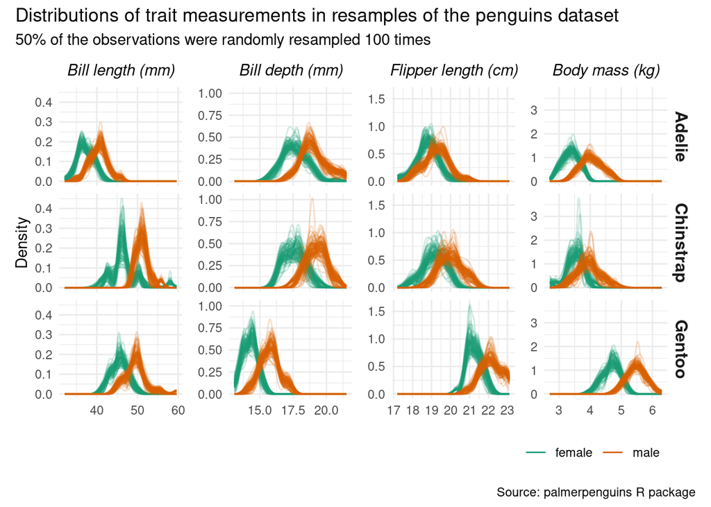

**Note**: originally tried building this plot buy pivoting the data to long format at facetting by species and measure (bill length, etc.), but `facet_grid()` doesn’t allow for free y axes on each pane so density doesn’t scale properly…). There’s a workaround with `facet_wrap(~ a*b)` but that creates bad labels and makes it hard to compare distributions across species.